# PML Prediction Assignment Writeup

### Synopsis

Devices such as Jawbone Up, Nike FuelBand, and Fitbit enable the collection of large amounts of data about personal activity. These devices are part of the quantified self movement. With these devices people quantify how much of a particular activity they perform, but they rarely quantify how well they perform those activities.

In this project (part of the Johns Hopkins University Practical Machine Learning class on Coursera) we are working with sensor data collected from 6 individuals that performed a specific weight lifting activity. The collected data is used to train statistical models that predict whether an individual has performed the weight lifting activity correctly or not. For additional information about the data and how it was collected please refer to the following paper.

Velloso, E.; Bulling, A.; Gellersen, H.; Ugulino, W.; Fuks, H. [Qualitative Activity Recognition of Weight Lifting Exercises](http://groupware.les.inf.puc-rio.br/work.jsf?p1=11201). Proceedings of 4th International Conference in Cooperation with SIGCHI (Augmented Human ’13) . Stuttgart, Germany: ACM SIGCHI, 2013.

#### Analysis Environment

This analysis was last run on Sun Oct 26 11:44:24 2014 using [RStudio 0.98.1062](http://www.rstudio.com/) and [R version 3.1.1 (2014-07-10)](http://www.r-project.org/). The following libraries were used.

```r
library(caret)
library(dplyr)
```

### Data Processing and Cleaning

The file **pml-training.csv** contains the raw sensor data to be used for training the statistical models and performing cross validation. The file **pml-testing.csv** contains a set of 20 samples that will be used with the trained models to predict the associated activity. The data from this file is never used in the training of the models.

The raw files use NA and an empty quoted string to denote NA values. The files may also contain the string **#DIV/0!** which indicates that a computation involving sensor data failed during collection. We treat all of these as NA values.

```r
pmlFolder = Sys.getenv("PML")
setwd(pmlFolder)

naValues = c("#DIV/0!", "NA", "")

training <- read.table("pml-training.csv", header=T, sep=",", na.strings=naValues)
testing <- read.table("pml-testing.csv", header=T, sep=",", na.strings=naValues)
```

Looking at the data one can see that some of the columns contain values used to label or index each sample in the file. Most of these are of little value for training and prediction so we removed them from the test and training sets. We will keep **num_window** because it will be useful for aggregating the data later on. We also keep **classe** which is the variable to be predicted by the models.

```r
training <- select(training, num_window, classe, roll_belt:magnet_forearm_z)
testing <- select(testing, num_window, problem_id, roll_belt:magnet_forearm_z)
```

Looking further at the data one can see that some columns contain a lot of NA values. These columns are used to hold descriptive statistics calculated one time for each window in the data set. Colunmns with near zero variance can cause problems when training some models so we will remove them from the data sets. Now we calculate the percent of NAs in each column and the total NA count.

```r
naSummary <- data.frame(pctNAs=apply(training, 2, function(c) sum(is.na(c)) / length(c)),
                        totalNAs=apply(training, 2, function(c) sum(is.na(c))))

head(naSummary, 20)
```

```
##                         pctNAs totalNAs
## num_window           0.0000000        0
## classe               0.0000000        0
## roll_belt            0.0000000        0
## pitch_belt           0.0000000        0
## yaw_belt             0.0000000        0
## total_accel_belt     0.0000000        0
## kurtosis_roll_belt   0.9798186    19226
## kurtosis_picth_belt  0.9809398    19248
## kurtosis_yaw_belt    1.0000000    19622
## skewness_roll_belt   0.9797676    19225
## skewness_roll_belt.1 0.9809398    19248
## skewness_yaw_belt    1.0000000    19622
## max_roll_belt        0.9793089    19216
## max_picth_belt       0.9793089    19216
## max_yaw_belt         0.9798186    19226
## min_roll_belt        0.9793089    19216
## min_pitch_belt       0.9793089    19216
## min_yaw_belt         0.9798186    19226
## amplitude_roll_belt  0.9793089    19216
## amplitude_pitch_belt 0.9793089    19216
```

Some columns are approxiamtely 98% NA while others contain no NA values. We table the total NA counts to see how the NAs are distributed.

```r
table(naSummary$totalNAs)
```

```
##
##     0 19216 19217 19218 19220 19221 19225 19226 19227 19248 19293 19294 19296 19299 19300 19301 19622
##    54    67     1     1     1     4     1     4     2     2     1     1     2     1     4     2     6
```

So it appears that only about 54 of the original columns are potentially useable for training a model (those columns containing no NA values). We remove the other columns from the training and test data sets.

```r
nearZeroColumns <- row.names(naSummary[naSummary$totalNAs > 0,])
training = select(training, -one_of(nearZeroColumns))
testing = select(testing, -one_of(nearZeroColumns))
```

There are a number of other issues in the data (windows with very few samples, some sensor readings appear to be misformatted, etc.), but we are going to ignore those and use aggregation to smooth over the rough spots. The assumption here is that the majority of the data is reasonable and these problems will be averaged away when we aggregate the data.

### Data Aggregation and Covariate Creation

Now let’s look at the distribution of values in the predicted column to see how many samples we have to work with. There are 5 possible values from **A** to **E** where **A** represents sensor samples for the weight lifting action performed correctly. The other values represent the action being performed incorrectly in some way.

```r
table(training$classe)
```

```
##
##    A    B    C    D    E
## 5580 3797 3422 3216 3607
```

The test data used to make predictions in the final part of this project consists of 20 different samples each taken from a diffrent window. This means the aggregation that we apply to the training data and any covariates that we create must be meaningful when applied to the test data set. For example, calculating the standard deviation for each column in each window of the training data would give us nice summary values, but they would be useless for prediction. Applying the same transformation to the test data would yield all NA values. That is, the standard deviation of a single value is NA. Recall that each window in the test set contains one sample (row).

The most useful aggregation (and covariate creation) in this case is to calculate the mean for each column in each window of the training data set. Applying the mean to the test data set columns will return the same value (the mean of a column with a single value is the value in the column). Therefore the aggregation essentially leaves the test data as-is. The aggregations are applied below.

```r
byNumWindow <- group_by(training, num_window, classe)
newTraining <- summarise_each(byNumWindow, funs(mean))

byNumWindow <- group_by(testing, num_window, problem_id)
newTesting <- summarise_each(byNumWindow, funs(mean))

table(newTraining$classe)
```

```
##
##   A   B   C   D   E
## 242 168 151 141 156
```

We still have a decent distribution of the predicted values. The next step is to use the training data to create a few models and see how they perform.

### Model Creation

First we need to withfold some of the aggregated training data so we can use it to estimate the “out of sample errors”. We split off 25% of the samples in the training set to be used as a validation test set. The validation test set is named **classeNewTesting** to distinguish it from the test data set loaded earlier.

```r
set.seed(3433)
inTrainingSet <- createDataPartition(newTraining$classe, p=3/4, list=F)
classeNewTraining <- newTraining[inTrainingSet,]
classeNewTesting <- newTraining[-inTrainingSet,]
```

Random forest models tend to have good accuracy for training data like the kind we have in this project. We train a random forrest model using 5 repetitions of 10-fold cross validation to improve overall accuracy. The training process will search for the best model over various values of the **mtry** tuning parameter. This parameter controls the number of randomly selected predictors.

```r
set.seed(3433)

cvCtrl <- trainControl(method = "repeatedcv", repeats = 5)

grid <- expand.grid(mtry = seq(20, 40, by = 5))

rfModel <- train(classe ~ ., data=classeNewTraining, method="rf",
                 tuneGrid=grid,
                 trControl = cvCtrl)

rfModel
```

```
## Random Forest
##
## 645 samples
##  53 predictor
##   5 classes: 'A', 'B', 'C', 'D', 'E'
##
## No pre-processing
## Resampling: Cross-Validated (10 fold, repeated 5 times)
##
## Summary of sample sizes: 582, 581, 581, 580, 580, 580, ...
##
## Resampling results across tuning parameters:
##
##   mtry  Accuracy  Kappa  Accuracy SD  Kappa SD
##   20    0.891     0.862  0.0356       0.0453
##   25    0.892     0.863  0.0342       0.0435
##   30    0.892     0.864  0.0351       0.0446
##   35    0.891     0.862  0.0370       0.0471
##   40    0.891     0.862  0.0361       0.0460
##
## Accuracy was used to select the optimal model using  the largest value.
## The final value used for the model was mtry = 30.
```

We get approximately 89% accuracy which is assumemd to be better than the actual accuracy we will see when the model is used for prediction with the testing data set. Plotting the model will give a sesne of the how the value of the tuning parameter affected the model’s accuracy.

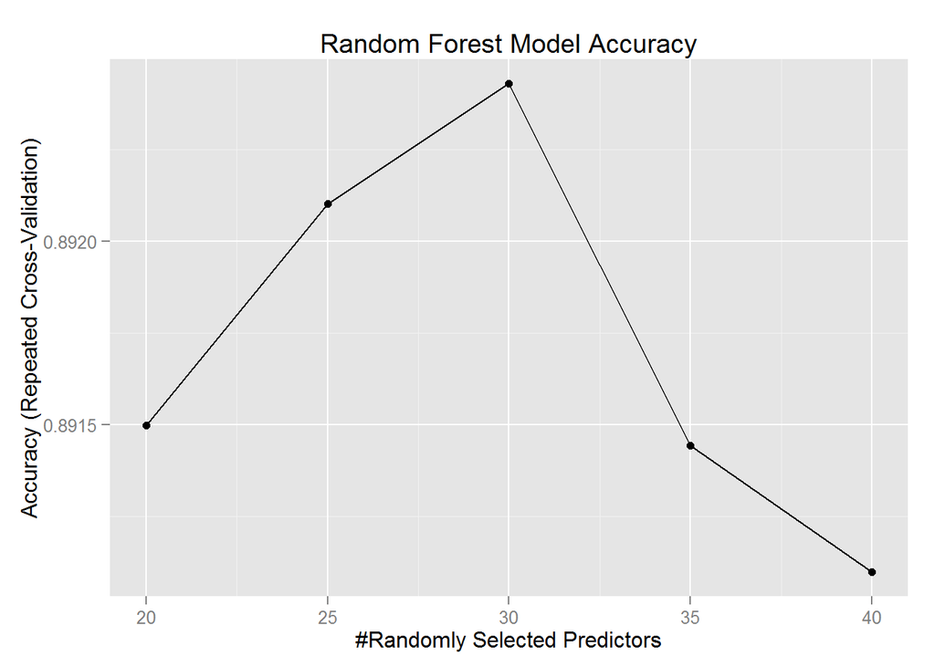

Thirty randomly selected predictors gives the best accuracy. The next model we will train is also based upon trees but uses stochastic gradient boosting to improve accuracy. As before we use 5 repetitions of 10-fold cross validation. The training process will also use a search grid that varies the tree depth, number of trees, and the learning rate.

```r
set.seed(3433)

cvCtrl <- trainControl(method = "repeatedcv", repeats = 5)

grid <- expand.grid(interaction.depth = seq(1, 7, by=2),
                    n.trees = seq(150, 250, by = 50),
                    shrinkage = c(0.1))

gbmModel <- train(classe ~ ., data = classeNewTraining, method="gbm",
                  tuneGrid=grid,
                  verbose=F,
                  trControl=cvCtrl)

gbmModel
```

```
## Stochastic Gradient Boosting
##
## 645 samples
##  53 predictor
##   5 classes: 'A', 'B', 'C', 'D', 'E'
##
## No pre-processing
## Resampling: Cross-Validated (10 fold, repeated 5 times)
##
## Summary of sample sizes: 582, 581, 581, 580, 580, 580, ...
##
## Resampling results across tuning parameters:
##
##   interaction.depth  n.trees  Accuracy  Kappa  Accuracy SD  Kappa SD
##   1                  150      0.844     0.803  0.0416       0.0529
##   1                  200      0.859     0.822  0.0427       0.0541
##   1                  250      0.873     0.839  0.0423       0.0535
##   3                  150      0.899     0.872  0.0356       0.0453
##   3                  200      0.902     0.876  0.0321       0.0407
##   3                  250      0.905     0.880  0.0341       0.0433
##   5                  150      0.910     0.886  0.0342       0.0435
##   5                  200      0.909     0.885  0.0365       0.0464
##   5                  250      0.911     0.887  0.0335       0.0425
##   7                  150      0.913     0.889  0.0333       0.0423
##   7                  200      0.913     0.889  0.0335       0.0426
##   7                  250      0.913     0.890  0.0299       0.0379
##
## Tuning parameter 'shrinkage' was held constant at a value of 0.1
## Accuracy was used to select the optimal model using  the largest value.
## The final values used for the model were n.trees = 250, interaction.depth = 7 and shrinkage = 0.1.
```

We get approximately 91% accuracy which is assuemd to be better than the actual accuracy we will see when the model is used for prediction with the testing data set. Plotting the model will give a sesne of the how the various tuning parameters affected the model’s accuracy.

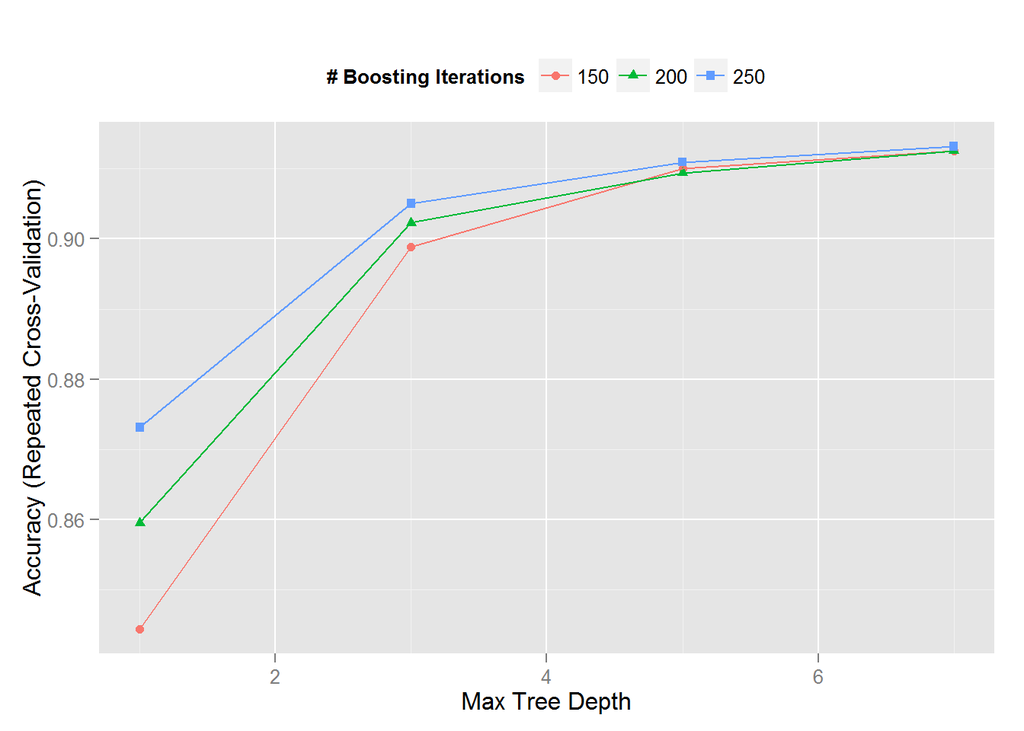

Using a tree depth of 7 is a good choice and we might be able to increase the accuracy slightly by using deeper trees, but the curves indicate we’re very close to the best accuracy that can be expected given the data and the model.

Given that the two models are so close in terms of accuracy let’s see how they compare to each other when making predictions for the withheld validation test data.

```r
rfPredictions <- predict(rfModel, classeNewTesting)
gbmPredictions <- predict(gbmModel, classeNewTesting)
table(rfPredictions,gbmPredictions)
```

```
##              gbmPredictions
## rfPredictions  A  B  C  D  E
##             A 55  6  1  0  3
##             B  0 39  3  0  2
##             C  1  2 35  1  1
##             D  1  1  1 28  0
##             E  1  0  0  1 31
```

They are mostly in agreement. Now we look at the Confusion matrix for the predictions made by the random forest model and the actual **classe** values from the validation test data set.

```r
confusionMatrix(rfPredictions, classeNewTesting$classe)
```

```
## Confusion Matrix and Statistics
##
##           Reference
## Prediction  A  B  C  D  E
##          A 56  4  2  1  2
##          B  2 33  7  0  2
##          C  1  4 28  3  4
##          D  0  1  0 29  1
##          E  1  0  0  2 30
##
## Overall Statistics
##
##                Accuracy : 0.8263
##                  95% CI : (0.7686, 0.8746)
##     No Information Rate : 0.2817
##     P-Value [Acc > NIR] : <2e-16
##
##                   Kappa : 0.7797
##  Mcnemar's Test P-Value : 0.1978
##
## Statistics by Class:
##
##                      Class: A Class: B Class: C Class: D Class: E
## Sensitivity            0.9333   0.7857   0.7568   0.8286   0.7692
## Specificity            0.9412   0.9357   0.9318   0.9888   0.9828
## Pos Pred Value         0.8615   0.7500   0.7000   0.9355   0.9091
## Neg Pred Value         0.9730   0.9467   0.9480   0.9670   0.9500
## Prevalence             0.2817   0.1972   0.1737   0.1643   0.1831
## Detection Rate         0.2629   0.1549   0.1315   0.1362   0.1408
## Detection Prevalence   0.3052   0.2066   0.1878   0.1455   0.1549
## Balanced Accuracy      0.9373   0.8607   0.8443   0.9087   0.8760
```

The models accuracy dropped to 83% which is likely due to being slightly overfit even though we used repeated n-fold cross validation in training. Now we look at the confusion matrix for the predictions made by the GBM model and the actual values from the validation test data set.

```r
confusionMatrix(gbmPredictions, classeNewTesting$classe)
```

```
## Confusion Matrix and Statistics
##
##           Reference
## Prediction  A  B  C  D  E
##          A 54  2  0  1  1
##          B  5 36  6  0  1
##          C  1  3 31  3  2
##          D  0  0  0 29  1
##          E  0  1  0  2 34
##
## Overall Statistics
##
##                Accuracy : 0.8638
##                  95% CI : (0.8104, 0.9069)
##     No Information Rate : 0.2817
##     P-Value [Acc > NIR] : < 2.2e-16
##
##                   Kappa : 0.8279
##  Mcnemar's Test P-Value : NA
##
## Statistics by Class:
##
##                      Class: A Class: B Class: C Class: D Class: E
## Sensitivity            0.9000   0.8571   0.8378   0.8286   0.8718
## Specificity            0.9739   0.9298   0.9489   0.9944   0.9828
## Pos Pred Value         0.9310   0.7500   0.7750   0.9667   0.9189
## Neg Pred Value         0.9613   0.9636   0.9653   0.9672   0.9716
## Prevalence             0.2817   0.1972   0.1737   0.1643   0.1831
## Detection Rate         0.2535   0.1690   0.1455   0.1362   0.1596
## Detection Prevalence   0.2723   0.2254   0.1878   0.1408   0.1737
## Balanced Accuracy      0.9369   0.8935   0.8934   0.9115   0.9273
```

The models accuracy dropped to 86% which is also due to some overfitting. However, the GBM model performs slightly better than the random forest model therefore it will be used to generate the predictions to be submitted for grading the assignment. Predictions are made using the **newTesting** variable which contains the testing data read from the CSV file in the first part of this project.

```r
newTesting <- newTesting[order(newTesting$problem_id),]
assignmentPredictions <- predict(gbmModel, newTesting)

for (i in 1:length(assignmentPredictions)) {
    filename = paste0("problem_id_", i, ".txt")
    write.table(assignmentPredictions[i],
                file=filename,
                quote=F,
                row.names=F,
                col.names=F)
}
```